# Vaccine Estimates

Anthony Staines

2021-01-08

# Purpose

To examine a few simple deterministic scenarios for vaccine roll out for the new COVID19 vaccines.

# Starting assumptions

We have 4.9710^{6} people in Ireland. We need to vaccinate 3.97610^{6} of these for 80% coverage. This requires 7.95210^{6} doses of vaccine.

# Effect of different fixed vaccination rates

Suppose we start in Week 1 on the 2021-01-04.

We examine seven weekly vaccination rates (from Week 1). We ignore supply issues, holidays, and any other real life events. We assume we can do from 50k to 200k each week.

This gives us the following results :-

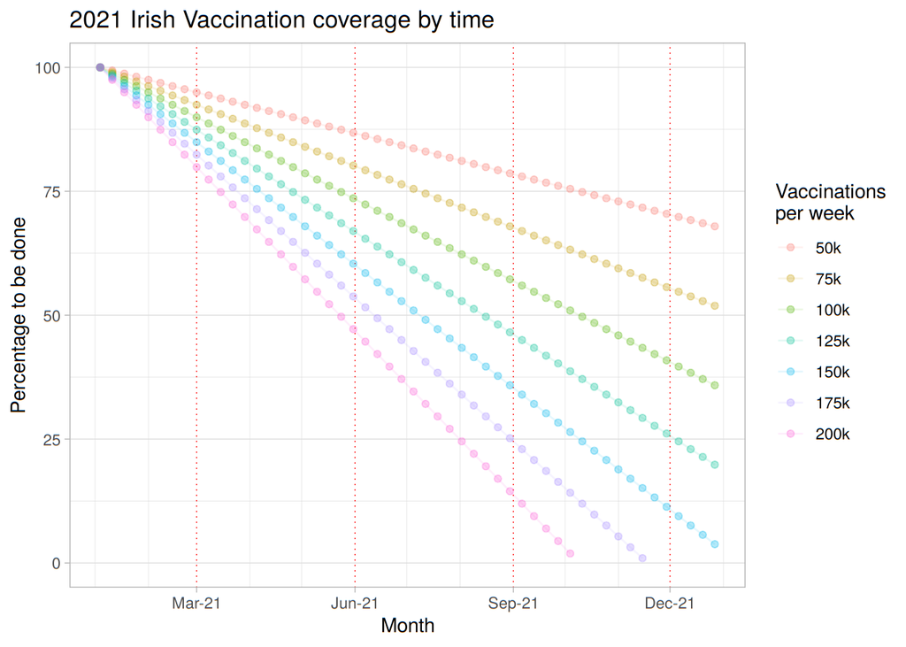

Unless we can deliver more than 150,000 doses of vaccine each week from now, we do not reach population coverage before Christmas.

# Scaled up vaccination over times

A more credible model is a scaled up vaccination over time. For simplicty we assume a constant rate of increase each week from 20,000 doses a week.

We start by lookign only at the effect of an increasing numebr of vaccinations a week, but with a very large maximum number of disease a week - 500,000.

This gives us the following picture :-

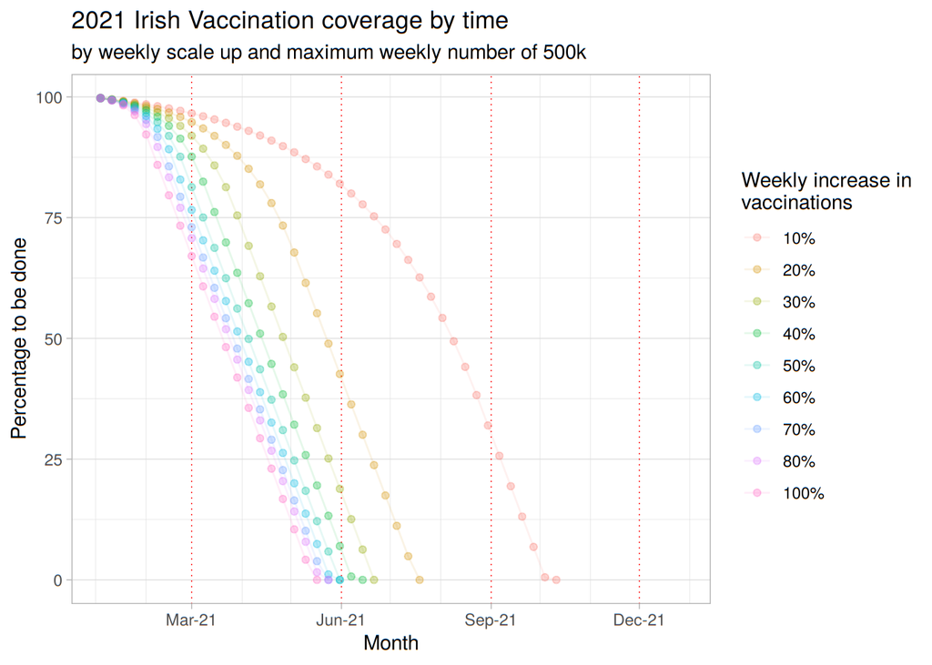

If our maximum is lower, say 250,000 we get this.

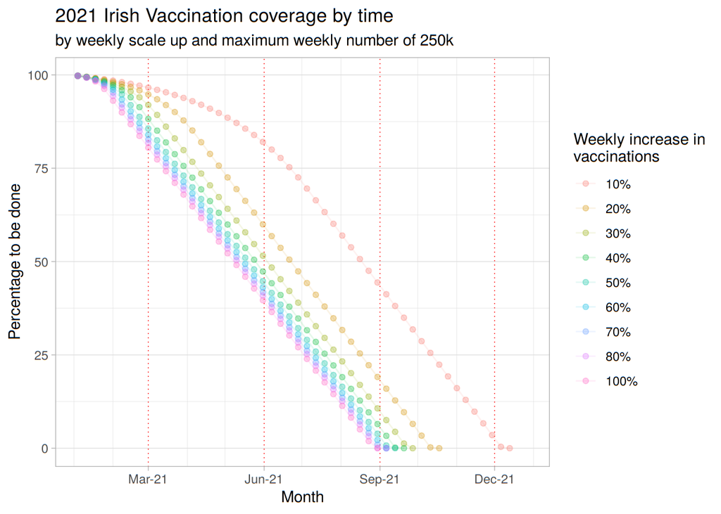

Again, this is positive, and for most scenarios we hit 80% coverage in September.

# Joint effects of rising weekly rates and different maximum vaccination rates

This suggests the merit of looking at both.

This gives us the following complex picture.

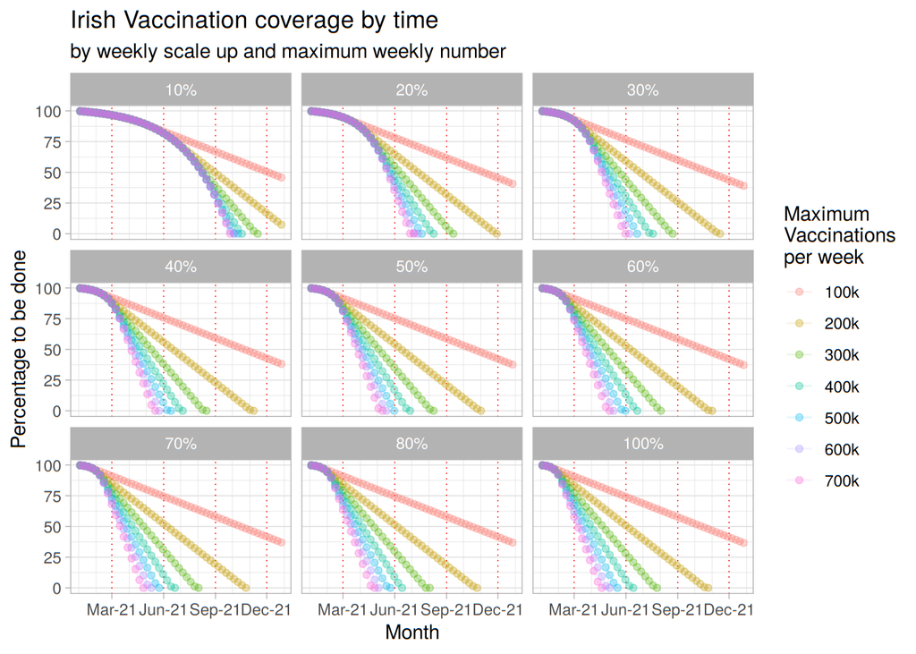

This complex graph shows two effects. As the maximum possible number of vaccinations rises, the length of time taken to completion falls.

As the rate of increase of vaccinations per week rises (10% a week, 20% a week, up to a 100% a week, which is doubling every week), the length of time taken to completion falls.

In almost any scenario in which the maximum number of vaccinations a week is over 200k, vaccination is completed before Christmas 2021, which is good news.

In relaity, none of these scenarios is credible. All assume that there no hitches with supply, and in fact that supply is not a limiting factor. This isnt true. The maximum number of vaccinations is determined by supply, and by capacity to vaccinate, both of whihc are rising. The number of vaccinations a week is determined by the same things. We expect over time, that the number of vaccinations that can be delivered will rise, but we also need to understand that some parts of the population can be reached much faster than others.

Real vaccination programs always have a maddeningly slow start-up, and a long tail, before adequate vaccination coverage is reached.